# Technical Analysis Challenge

CodeIT Suisse 2019

## Problem Statement

Use the first few *known* values of *stock price* as **training data** to recommend buy and sell trades for the next few *unknown* values of **test data**.

The price is modeled by the following function family:

\begin{equation} price_i(t_i) = base + trend * t_i + \sum_{w=1}^{sine\_count} scale_w * \sin(2\pi * period\_count_w * t_i) \end{equation}

**Training data** values are *truncated* to integers. **Test data** is precise.

### Picture Worth a Thousand Words

Illustrative example of sine_count=1 with 30 values of training data and 60 values of test data

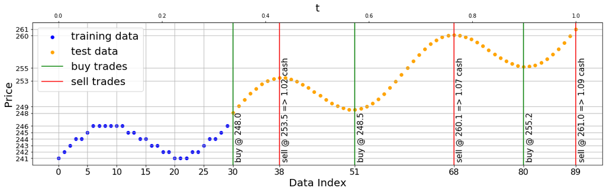

```
Training data - your input (blue line):
[241, 242, 243, 244, 244, 245, 246, 246, 246, 246, 246, 246, 245, 245, 244, 244, 243, 243, 242, 242, 241, 241,
 241, 242, 242, 243, 244, 244, 245, 246]

Test data - you won't see it (orange line):
[248.0237288698771, 249.08090060113744, 250.08826187106925, 251.01083737788557, 251.8174407897403,
 252.4820684229782, 252.98506131430463, 253.31398375532103, 253.46417902881325, 253.43897751163246,
 253.24954784430986, 252.91439781844994, 252.4585472866212, 251.91241005636977, 251.3104347351166,
 250.6895652648834, 250.08758994363023, 249.5414527133788, 249.0856021815501, 248.75045215569014,
 248.56102248836754, 248.53582097118675, 248.68601624467897, 249.01493868569537, 249.5179315770218,
 250.1825592102597, 250.98916262211443, 251.91173812893075, 252.91909939886256, 253.97627113012288,
 255.0460520535713, 256.0906774110047, 257.0735066150713, 257.96066067139145, 258.72253618853586,
 259.3351283166435, 259.7811034942037, 260.050574063288, 260.1415401366431, 260.05997897015624,
 259.81957784674927, 259.4411224087867, 258.9515677736589, 258.38283394322565, 257.7703793387695,
 257.1516162084004, 256.56423872037846, 256.0445384577765, 255.62578259292454, 255.33672721899555,
 255.20033227608943, 255.2327355001637, 255.44253124775366, 255.8303864249044, 256.3890106839719,
 257.1034822201611, 257.95191460835974, 258.90643488016235, 259.9344291320425, 261.0]

Optimal trades - the output you need to produce (alternating green and red lines):
[30, 38, 51, 68, 80, 89]

Max final amount of cash is 1.09

This example uses the following function family parameters:
Base=241, trend=20, scale=4, period_count=3, sine_count=1
```

### Rules and Assumptions

**Training data** is immediately followed by **test data** with their values **price[i]** indexed as

\begin{align*} &i \in [0,{training\_size + test\_size - 1}] \\ and \\ &t_i = \dfrac{i}{training\_size + test\_size - 1} \in [0,1] \end{align*}

Price model parameter boundaries: \begin{align*} &base \in [200, 300) \\ &trend \in [-100, 100) \\ &scale_i \in [5, 15) \\ &period\_count_i \in [10, 100) \\ &price_i > 0 \end{align*}

Initial amount of cash is 1.

First trade is a "buy". Trade sequence consists of alternating "buy" and "sell" trades.

If the last recommended trade is a "buy" (i.e. recommendation contains odd number of indexes), then a "sell" will be implied at the last index.

Every trade is full, i.e.:

- "buy" converts all cash to stock
- "sell" converts all stock back to cash

Solution timeout is 28 seconds.

### Input

You will receive **training data** for 4 scenarios in separate arrays, each containing 100 values. See Scoring section below with explanation of scenarios.

### Output

You need to produce trade recommendations sequences for all 4 input scenarios. Each recommendation sequence will be applied to corresponding **test data** to calculate the final cash amount. Every **test data** sequence contains 1,000 values indexed [100, 1099]. So every trade recommendation sequence should be monotonically increasing within [100, 1099] and is assumed to contain alternating buy-sell indexes.

#### Sample Input

Each input contains training data for 4 scenarios, for example:

```
[[283, 285, 287, 288, 290, 291, 291, 291, 290, 289, 287, 285, 283, 280, 278, 276, 275, 273, 273, 273, 273,
  274, 276, 277, 279, 282, 284, 286, 287, 289, 289, 290, 289, 288, 287, 285, 283, 281, 279, 276, 275, 273,
  272, 271, 271, 272, 273, 275, 277, 279, 281, 283, 285, 286, 288, 288, 288, 288, 287, 285, 283, 281, 279,
  277, 275, 273, 271, 270, 270, 270, 271, 272, 274, 276, 278, 280, 282, 284, 285, 286, 287, 287, 286, 285,
  284, 282, 279, 277, 275, 273, 271, 270, 269, 269, 269, 270, 271, 273, 275, 277],
 [268, 273, 277, 280, 281, 280, 277, 273, 268, 264, 261, 259, 259, 261, 263, 266, 269, 271, 271, 270, 268,
  265, 262, 260, 259, 259, 261, 265, 269, 274, 278, 280, 280, 278, 275, 270, 264, 259, 255, 253, 253, 255,
  258, 262, 267, 271, 273, 274, 274, 272, 269, 266, 263, 262, 262, 264, 266, 269, 272, 274, 274, 273, 270,
  266, 261, 257, 253, 252, 252, 255, 259, 264, 270, 274, 278, 279, 278, 276, 272, 267, 263, 259, 257, 257,
  258, 261, 263, 266, 268, 269, 268, 266, 263, 260, 258, 257, 257, 259, 262, 266],
 [239, 251, 261, 269, 272, 270, 264, 255, 245, 234, 224, 218, 214, 215, 219, 226, 234, 242, 249, 253, 255,
  253, 250, 245, 240, 236, 233, 232, 234, 237, 241, 246, 250, 252, 252, 250, 247, 242, 237, 232, 229, 228,
  228, 231, 235, 240, 245, 249, 252, 254, 254, 252, 250, 247, 245, 243, 242, 242, 242, 242, 242, 242, 240,
  238, 236, 233, 232, 232, 234, 238, 243, 250, 257, 263, 267, 269, 267, 262, 255, 245, 235, 226, 220, 216,
  217, 222, 229, 240, 250, 260, 268, 272, 273, 269, 262, 253, 244, 236, 230, 227],
 [270, 282, 292, 299, 302, 300, 295, 287, 279, 273, 268, 266, 266, 269, 272, 274, 275, 273, 269, 264, 259,
  254, 252, 253, 256, 261, 267, 273, 276, 277, 275, 271, 265, 259, 255, 253, 255, 261, 269, 278, 287, 293,
  295, 293, 287, 279, 269, 260, 253, 249, 249, 253, 258, 265, 272, 276, 278, 278, 276, 273, 270, 269, 269,
  271, 275, 278, 280, 281, 278, 272, 264, 255, 247, 241, 239, 240, 246, 255, 266, 276, 284, 288, 289, 286,
  280, 273, 267, 263, 262, 264, 269, 275, 281, 285, 287, 286, 282, 276, 269, 263]]
```

#### Sample Output

```
[[100, 105, 118, 130, 143, 155, 167, 180, 192, 204, 217, 229, 242, 254, 266, 279, 291, 303, 316, 328, 341, 353, 366,
  378, 390, 403, 415, 427, 440, 452, 465, 477, 489, 502, 514, 526, 539, 551, 564, 576, 589, 601, 613, 625, 638, 650,
  663, 675, 688, 700, 712, 725, 737, 749, 762, 774, 787, 799, 811, 824, 836, 848, 861, 873, 886, 898, 911, 923, 935,
  948, 960, 972, 985, 997, 1010, 1022, 1034, 1047, 1059, 1071, 1084, 1096],
 [100, 103, 111, 118, 125, 131, 138, 146, 154, 160, 167, 174, 182, 189, 196, 202, 210, 218, 225, 231, 238, 245, 253,
  261, 267, 273, 281, 289, 296, 303, 309, 316, 324, 332, 338, 345, 352, 360, 367, 374, 380, 388, 396, 403, 409, 416,
  423, 431, 439, 445, 451, 459, 467, 474, 481, 487, 494, 502, 510, 516, 523, 530, 538, 545, 552, 558, 566, 574, 581,
  587, 594, 601, 609, 617, 623, 629, 637, 645, 652, 659, 665, 672, 680, 688, 694, 700, 708, 716, 723, 730, 736, 744,
  752, 759, 765, 772, 779, 787, 795, 801, 807, 815, 823, 830, 837, 843, 850, 858, 866, 872, 879, 886, 894, 901, 908,
  914, 922, 929, 937, 943, 950, 957, 965, 973, 979, 985, 993, 1001, 1008, 1015, 1021, 1028, 1036, 1044, 1050, 1056,
  1064, 1072, 1079, 1086, 1092, 1099],
 [100, 107, 114, 121, 130, 138, 147, 151, 154, 163, 171, 179, 186, 193, 201, 209, 217, 225, 233, 240, 246, 254, 261,
  268, 272, 280, 288, 296, 305, 312, 320, 327, 334, 343, 351, 367, 376, 384, 392, 399, 406, 414, 422, 430, 439, 446,
  452, 458, 465, 473, 479, 485, 493, 501, 510, 518, 525, 533, 540, 547, 556, 564, 580, 589, 597, 605, 612, 619, 627,
  635, 643, 652, 659, 663, 669, 678, 685, 692, 698, 706, 714, 723, 731, 739, 745, 752, 760, 768, 777, 778, 785, 793,
  802, 810, 818, 825, 832, 840, 848, 857, 865, 871, 873, 882, 890, 898, 905, 912, 919, 927, 936, 944, 952, 958, 965,
  972, 980, 987, 991, 998, 1007, 1015, 1023, 1031, 1038, 1045, 1053, 1061, 1070, 1086, 1094, 1099],
 [102, 106, 112, 120, 128, 133, 139, 145, 152, 158, 165, 173, 180, 183, 190, 198, 205, 211, 218, 224, 228, 236, 244,
  250, 256, 262, 268, 275, 282, 289, 297, 301, 306, 314, 321, 327, 334, 341, 346, 352, 360, 367, 374, 379, 385, 392,
  398, 405, 413, 420, 422, 430, 438, 444, 451, 458, 464, 469, 475, 483, 491, 496, 502, 509, 515, 521, 529, 537, 541,
  546, 554, 560, 567, 574, 581, 586, 591, 599, 607, 614, 618, 625, 632, 637, 645, 653, 659, 663, 670, 677, 684, 691,
  697, 704, 708, 715, 723, 730, 736, 742, 749, 754, 761, 769, 776, 781, 786, 793, 801, 807, 814, 821, 826, 831, 839,
  847, 853, 859, 865, 871, 877, 884, 892, 899, 903, 909, 917, 924, 930, 937, 945, 947, 955, 963, 970, 976, 982, 988,
  994, 1001, 1008, 1016, 1022, 1025, 1033, 1040, 1046, 1054, 1061, 1066, 1071, 1079, 1086, 1093]]
```

### Scoring

Input data contains 4 scenarios in this order:

| Scenario | sine_count | weight |
| --- | --- | --- |
| 1 | 1 | 0.1 |
| 2 | 2 | 0.2 |
| 3 | 3 | 0.3 |
| 4 | 4 | 0.4 |

Assuming the initial amount of cash is 1, scenario score is:

\begin{equation} score_s = \max(0, \dfrac{final\_cash_s - 1}{max\_final\_cash_s - 1}) \end{equation}

Where

- **final_cash** - final amount of cash after trading on your recommendations
- **max_final_cash** - final amount of cash after trading on optimal strategy a.k.a. "buy low, sell high"

Total score is:

\begin{equation} total\_coorinator\_score = \lceil{100 * \sum_{s=1}^{scenario\_count} weight_s * score_s}\rceil \end{equation}

### Some Inspirational Visualization

**Blue** - training data  
**Orange** - test data

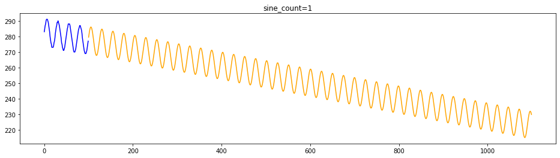

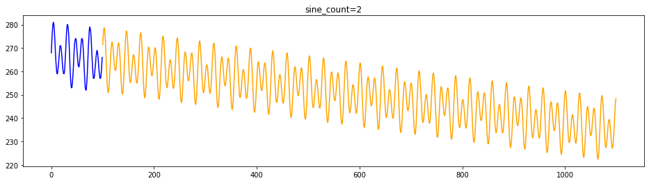

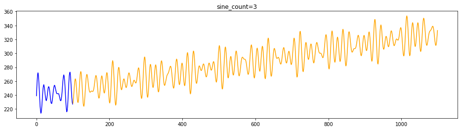

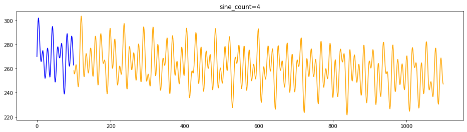

Since you've scrolled this far, here's a Python code snippet to generate more training data:

```
import numpy as np
import matplotlib.pyplot as plt

def generate_price(random_seed, sine_count):
    rnd = np.random.RandomState(random_seed)
    train_size = 100
    test_size = 1_000
    size = train_size + test_size
    t = np.linspace(0, 1, num=size)

    base = rnd.uniform(200, 300)
    trend = rnd.uniform(-100, 100)
    price = np.full(size, base) + trend * t
    for _ in range(sine_count):
        scale = rnd.uniform(5, 15)
        period_count = rnd.uniform(10, 100)
        price += scale * np.sin(2 * np.pi * period_count * t)

    return price[:train_size].astype(np.int), price[-test_size:]

# And here's how to generate and visualize the data
train, test = generate_price(random_seed=1, sine_count=2)
fig = plt.figure()
fig.set_size_inches(16, 4)
plt.plot(np.arange(train.shape[0]), train)
plt.plot(train.shape[0] + np.arange(test.shape[0]), test)
plt.show()
```